# chapter6.Rmd

Wenhsuan Hung

2019/12/5

# Analysis of longitudinal data

In this week, there are two datasets, which are BPRS and RATS. First, I transform both dataset into long form. I will start from interpreting RATS dataset.

**I.RATS dataset**

**Plot the RATS data** I draw two plots to show the result of different groups. X-axis is Time, and Y-axis is Weight. Each color represents each group.

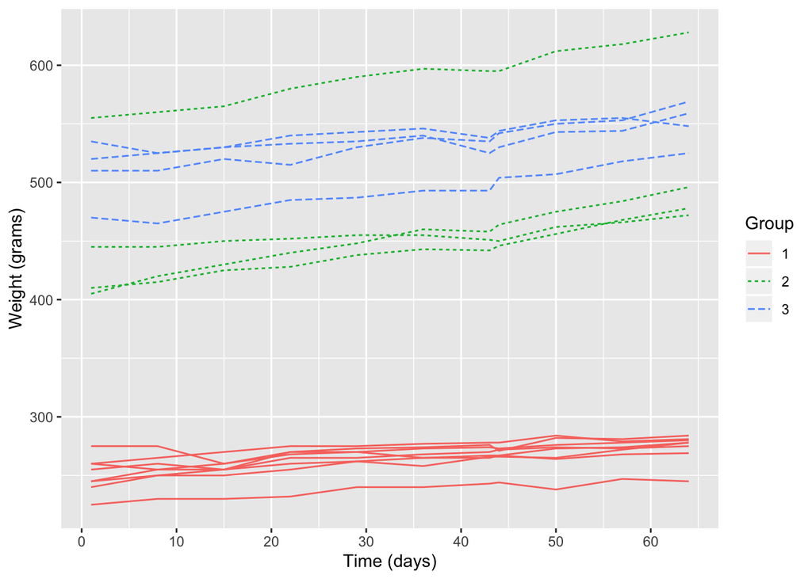

The result shows that the data of each group are distributed separately. Group 1 has the lowest weight as the time pass.

**The Golden Standardize** Since I want to see more clearly about the tracking phenomenon, I standardize values of each observation. Each line represents each group, the X-axis is Time, and Y-axis is standardized bprs.

[output not shown]

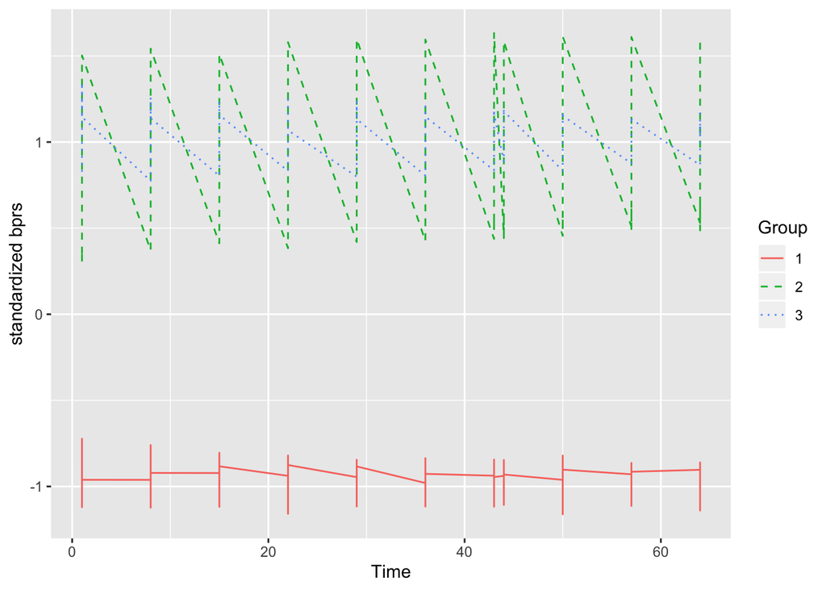

**Graphs showing average value**

**1.Summary graphs -Plot the mean profiles**

Since tracking phenomenon only shows the rise and fall on the data, I couldn’t analysis the data clearly, hence graphs showing average value for each group, and the variation of the observations is important. It is better to study the average instead of each specific data in a huge dataset. I draw a summary graph showing the dataset.

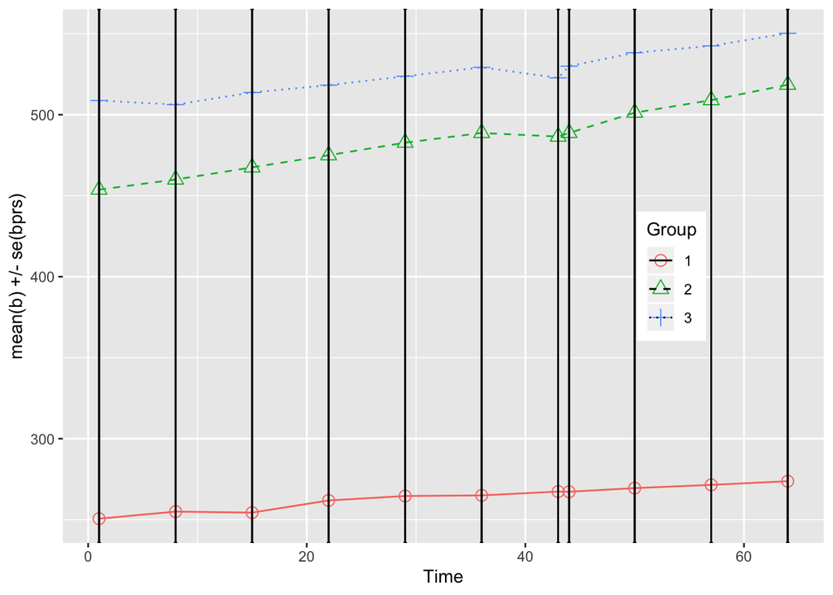

The summary graph shows the mean of each group in different time. This is clearer than the first two plots, since mean is better to interpret a big dataset (it shows the overall situation clearer). According to the plot, the mean of each group increases as the time pass.

**2.Find the Outlier**

Outliers might bias for the result, hence, in the next step, I try to find out the outliers and remove them from the dataset.**

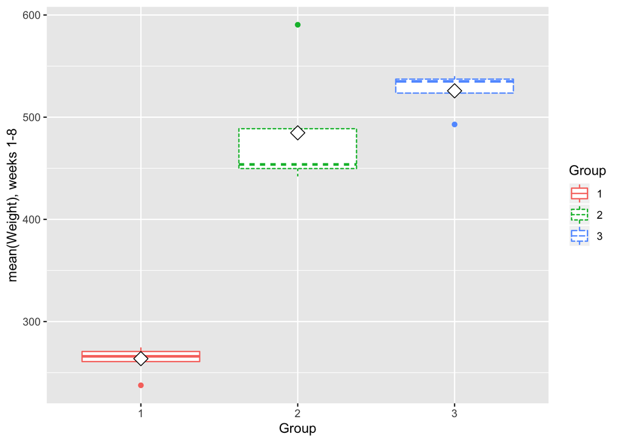

According to the boxplot, I find that all the three groups have outlier, hence I filter them out from the dataset, to make the result more unbiased.

** T-test and Anova**

```
## [1] 176   6
```

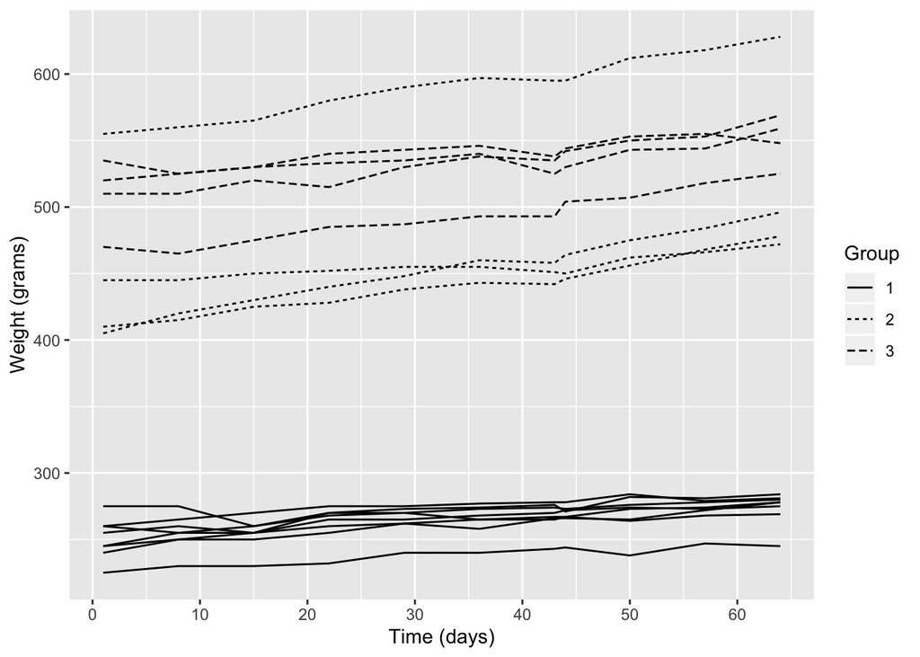

**Holding on to independence: The Linear model(Continuing to ignore the repeated-measures structure of the data, we will fit a multiple linear regression model with weight as response and Time and Group as explanatory variables.)**

```
##
## Call:
## lm(formula = Weight ~ Time + Group, data = RATSL)
##
## Residuals:
##     Min      1Q  Median      3Q     Max
## -60.643 -24.017   0.697  10.837 125.459
##
## Coefficients:
##             Estimate Std. Error t value Pr(>|t|)
## (Intercept) 244.0689     5.7725  42.281  < 2e-16 ***
## Time          0.5857     0.1331   4.402 1.88e-05 ***
## Group2      220.9886     6.3402  34.855  < 2e-16 ***
## Group3      262.0795     6.3402  41.336  < 2e-16 ***
## ---
## Signif. codes:  0 '***' 0.001 '**' 0.01 '*' 0.05 '.' 0.1 ' ' 1
##
## Residual standard error: 34.34 on 172 degrees of freedom
## Multiple R-squared:  0.9283, Adjusted R-squared:  0.9271
## F-statistic: 742.6 on 3 and 172 DF,  p-value: < 2.2e-16
```

**The Random Intercept Model(The previous model assumes independence of the repeated measures of weight, and this assumption is highly unlikely. So, now we will move on to consider both some more appropriate graphics and appropriate models. To begin the more formal analysis of the rat growth data, we will first fit the random intercept model for the same two explanatory variables: Time and Group. Fitting a random intercept model allows the linear regression fit for each rat to differ in intercept from other rats.We will use the lme4 package which offers efficient tools for fitting linear and generalized linear mixed-effects models. The first argument is the formula object describing both the fixed-effects and random effects part of the model, with the response on the left of a ~ operator and the terms, separated by + operators, on the right. Note the random-effects terms distinguished by vertical bars (|).)**

```
## Linear mixed model fit by maximum likelihood  ['lmerMod']
## Formula: Weight ~ Time + Group + (1 | ID)
##    Data: RATSL
##
##      AIC      BIC   logLik deviance df.resid
##   1333.2   1352.2   -660.6   1321.2      170
##
## Scaled residuals:
##     Min      1Q  Median      3Q     Max
## -3.5386 -0.5581 -0.0494  0.5693  3.0990
##
## Random effects:
##  Groups   Name        Variance Std.Dev.
##  ID       (Intercept) 1085.92  32.953
##  Residual               66.44   8.151
## Number of obs: 176, groups:  ID, 16
##
## Fixed effects:
##              Estimate Std. Error t value
## (Intercept) 244.06890   11.73107   20.80
## Time          0.58568    0.03158   18.54
## Group2      220.98864   20.23577   10.92
## Group3      262.07955   20.23577   12.95
##
## Correlation of Fixed Effects:
##        (Intr) Time   Group2
## Time   -0.090
## Group2 -0.575  0.000
## Group3 -0.575  0.000  0.333
```

** Slippery slopes: Random Intercept and Random Slope Model (Now we can move on to fit the random intercept and random slope model to the rat growth data. Fitting a random intercept and random slope model allows the linear regression fits for each individual to differ in intercept but also in slope. This way it is possible to account for the individual differences in the rats’ growth profiles, but also the effect of time.)**

```
## Linear mixed model fit by maximum likelihood  ['lmerMod']
## Formula: Weight ~ Time + Group + (Time | ID)
##    Data: RATSL
##
##      AIC      BIC   logLik deviance df.resid
##   1194.2   1219.6   -589.1   1178.2      168
##
## Scaled residuals:
##     Min      1Q  Median      3Q     Max
## -3.2258 -0.4323  0.0554  0.5635  2.8821
##
## Random effects:
##  Groups   Name        Variance Std.Dev. Corr
##  ID       (Intercept) 1138.783 33.7459
##           Time           0.112  0.3346  -0.22
##  Residual               19.750  4.4441
## Number of obs: 176, groups:  ID, 16
##
## Fixed effects:
##              Estimate Std. Error t value
## (Intercept) 246.51474   11.80983  20.874
## Time          0.58568    0.08541   6.857
## Group2      214.43334   20.17706  10.628
## Group3      258.85148   20.17706  12.829
##
## Correlation of Fixed Effects:
##        (Intr) Time   Group2
## Time   -0.164
## Group2 -0.569  0.000
## Group3 -0.569  0.000  0.333
## convergence code: 0
## Model failed to converge with max|grad| = 0.00952952 (tol = 0.002, component 1)
```

```
## Data: RATSL
## Models:
## RATS_ref: Weight ~ Time + Group + (1 | ID)
## RATS_ref1: Weight ~ Time + Group + (Time | ID)
##           Df    AIC    BIC  logLik deviance  Chisq Chi Df Pr(>Chisq)
## RATS_ref   6 1333.2 1352.2 -660.58   1321.2
## RATS_ref1  8 1194.2 1219.6 -589.11   1178.2 142.94      2  < 2.2e-16 ***
## ---
## Signif. codes:  0 '***' 0.001 '**' 0.01 '*' 0.05 '.' 0.1 ' ' 1
```

**Time to interact: Random Intercept and Random Slope Model with interaction (Finally, we can fit a random intercept and slope model that allows for a group × time interaction.)**

```
## Linear mixed model fit by maximum likelihood  ['lmerMod']
## Formula: Weight ~ Time * Group + (Time | ID)
##    Data: RATSL
##
##      AIC      BIC   logLik deviance df.resid
##   1185.9   1217.6   -582.9   1165.9      166
##
## Scaled residuals:
##     Min      1Q  Median      3Q     Max
## -3.2666 -0.4249  0.0726  0.6034  2.7510
##
## Random effects:
##  Groups   Name        Variance  Std.Dev. Corr
##  ID       (Intercept) 1.105e+03 33.2488
##           Time        4.924e-02  0.2219  -0.15
##  Residual             1.975e+01  4.4440
## Number of obs: 176, groups:  ID, 16
##
## Fixed effects:
##              Estimate Std. Error t value
## (Intercept) 251.65165   11.79308  21.339
## Time          0.35964    0.08215   4.378
## Group2      200.66549   20.42622   9.824
## Group3      252.07168   20.42622  12.341
## Time:Group2   0.60584    0.14228   4.258
## Time:Group3   0.29834    0.14228   2.097
##
## Correlation of Fixed Effects:
##             (Intr) Time   Group2 Group3 Tm:Gr2
## Time        -0.160
## Group2      -0.577  0.092
## Group3      -0.577  0.092  0.333
## Time:Group2  0.092 -0.577 -0.160 -0.053
## Time:Group3  0.092 -0.577 -0.053 -0.160  0.333
## convergence code: 0
## Model failed to converge with max|grad| = 0.00701626 (tol = 0.002, component 1)
```

```
## Data: RATSL
## Models:
## RATS_ref1: Weight ~ Time + Group + (Time | ID)
## RATS_ref2: Weight ~ Time * Group + (Time | ID)
##           Df    AIC    BIC  logLik deviance  Chisq Chi Df Pr(>Chisq)
## RATS_ref1  8 1194.2 1219.6 -589.11   1178.2
## RATS_ref2 10 1185.9 1217.6 -582.93   1165.9 12.361      2    0.00207 **
## ---
## Signif. codes:  0 '***' 0.001 '**' 0.01 '*' 0.05 '.' 0.1 ' ' 1
```

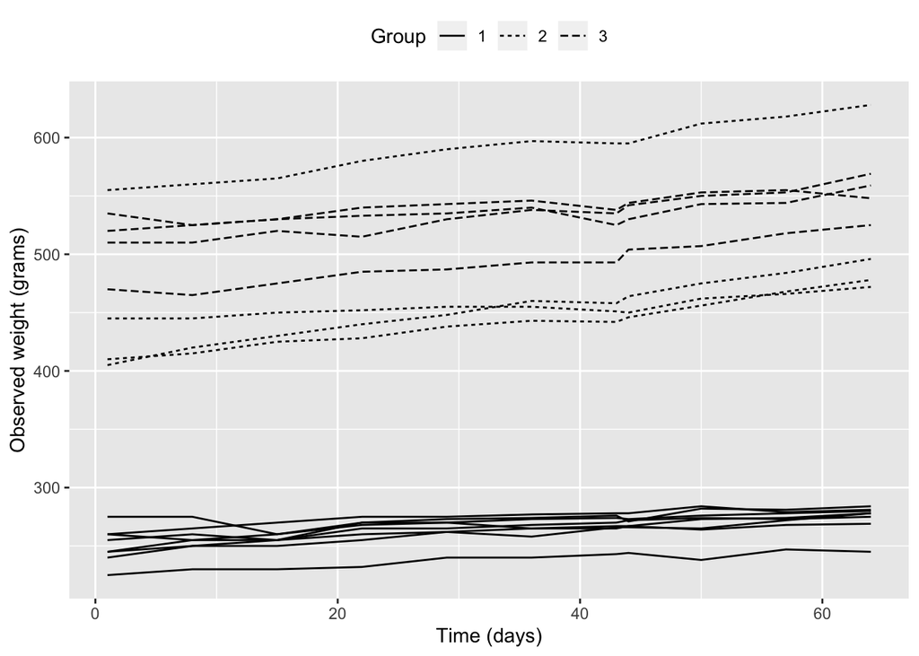

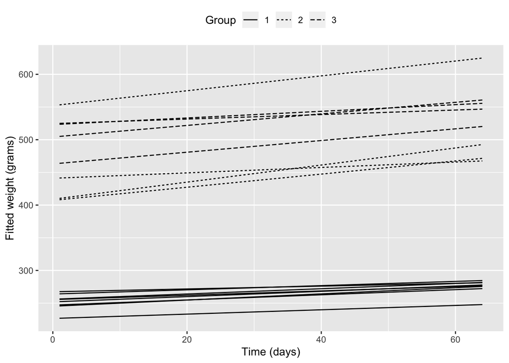